# ML_assignment2

### **Group_219** | **Dataset: Diabetes**

```
Group Member 1: Aman Kushwaha | Bits Id: 2022AC05577
Group Member 2: Vivek Kumar | Bits Id: 2022AC05491
Group Member 3: Roshan Kumar | Bits Id: 2022AC05572
```

### Import Libraries/Dataset

1. Download the dataset
2. Import the required libraries

```python
import pandas as pd
import matplotlib.pyplot as plt
import seaborn as sns
import numpy as np
```

```python
data=pd.read_csv('diabetes.csv')
```

# Data Visualization and Exploration

1. Print 2 rows for sanity check to identify all the features present in the dataset and if the target matches with them.
2. Comment on class imbalance with appropriate visualization method.
3. Provide appropriate visualizations to get an insight about the dataset.
4. Do the correlational analysis on the dataset. Provide a visualization for the same. Will this correlational analysis affect the feature selection that you will perform in the next step? Justify your answer. Answers must have justification to be awarded marks.
5. Any other visualisation specific to the problem statement.

```python
# 1. Print 2 rows for sanity check to identify all the features present in the dataset and if the target matches with them.
data.head(2)
```

|  | Pregnancies | Glucose | BloodPressure | SkinThickness | Insulin | BMI | DiabetesPedigreeFunction | Age | Outcome |
| --- | --- | --- | --- | --- | --- | --- | --- | --- | --- |
| 0 | 6 | 148 | 72 | 35 | 0 | 33.6 | 0.627 | 50 | 1 |
| 1 | 1 | 85 | 66 | 29 | 0 | 26.6 | 0.351 | 31 | 0 |

1. Comment on class imbalance with appropriate visualization method.

Class imbalance in machine learning refers to a situation where the distribution of classes in a classification problem is uneven, with one class having significantly more or fewer instances than the others. This can occur naturally in real-world scenarios or due to biases in data collection. However, class imbalance poses challenges for machine learning algorithms.

We can look into data info for class imbalance and for data visualization as well.

```python
# 3. Provide appropriate visualizations to get an insight about the dataset.
# Information of all columns
data.info()
```

```
<class 'pandas.core.frame.DataFrame'>
RangeIndex: 768 entries, 0 to 767
Data columns (total 9 columns):
 #   Column                    Non-Null Count  Dtype
---  ------                    --------------  -----
 0   Pregnancies               768 non-null    int64
 1   Glucose                   768 non-null    int64
 2   BloodPressure             768 non-null    int64
 3   SkinThickness             768 non-null    int64
 4   Insulin                   768 non-null    int64
 5   BMI                       768 non-null    float64
 6   DiabetesPedigreeFunction  768 non-null    float64
 7   Age                       768 non-null    int64
 8   Outcome                   768 non-null    int64
dtypes: float64(2), int64(7)
memory usage: 54.1 KB
```

### Comment: We have no Null values in above dataset

```python
data.columns
```

```
Index(['Pregnancies', 'Glucose', 'BloodPressure', 'SkinThickness', 'Insulin',
       'BMI', 'DiabetesPedigreeFunction', 'Age', 'Outcome'],
      dtype='object')
```

### Comment: making a list of columns

```python
columns=data.columns.to_list()
columns
```

```
['Pregnancies',
 'Glucose',
 'BloodPressure',
 'SkinThickness',
 'Insulin',
 'BMI',
 'DiabetesPedigreeFunction',
 'Age',
 'Outcome']
```

```python
def check_class_imbalance(column_names):
    plt.figure(figsize=(8, 4))

    sns.countplot(data=data, x=column_names)
    plt.title(f'Class Imbalance for {column_names}')
    plt.show()
```

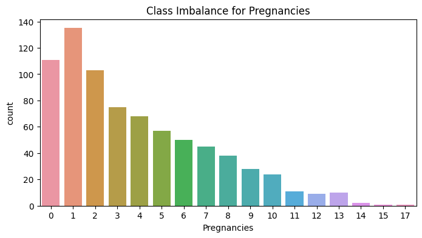

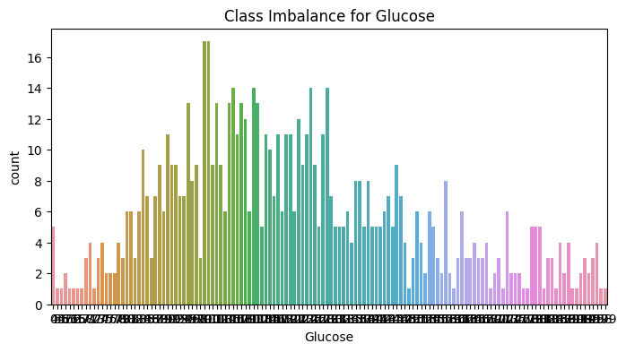

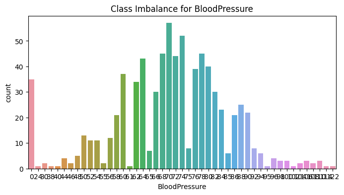

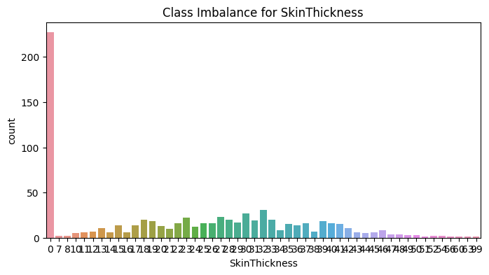

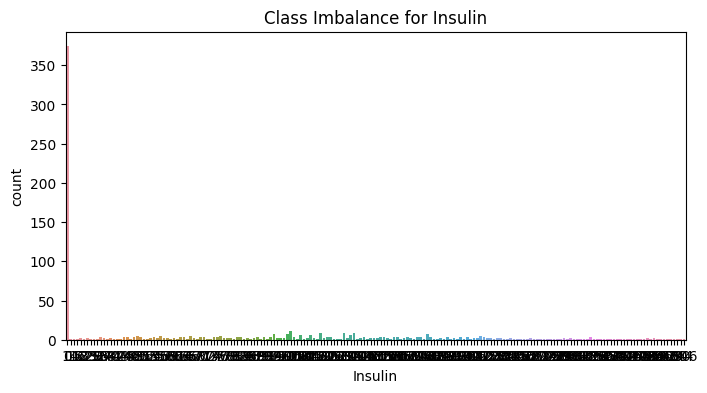

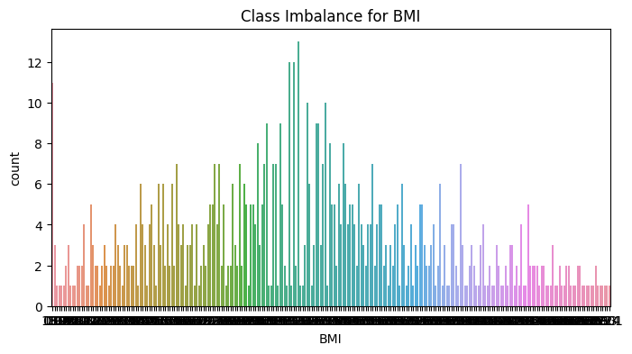

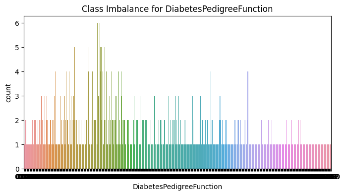

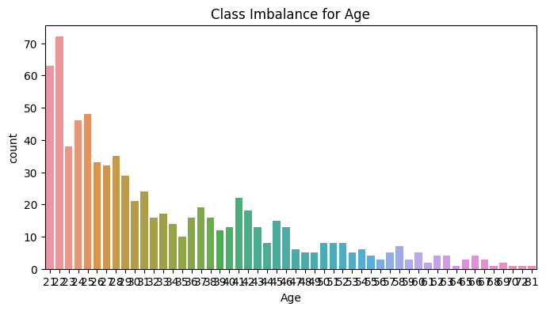

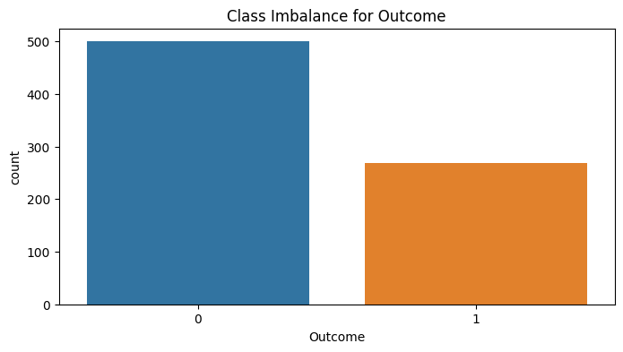

```python
# Check class imbalance for all columns
for column_name in data.columns.to_list():
    check_class_imbalance(column_name)
```

### Comment: Class Imbalance for all columns using countplot have been visualised above. using both Histogram and Countplot is visualised below:

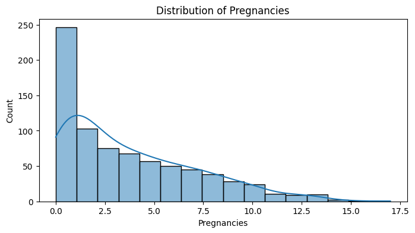

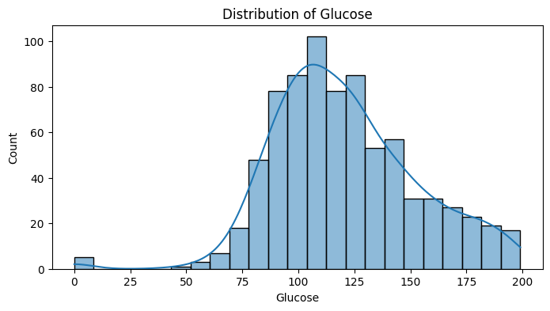

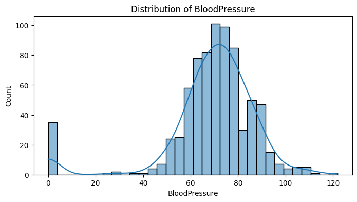

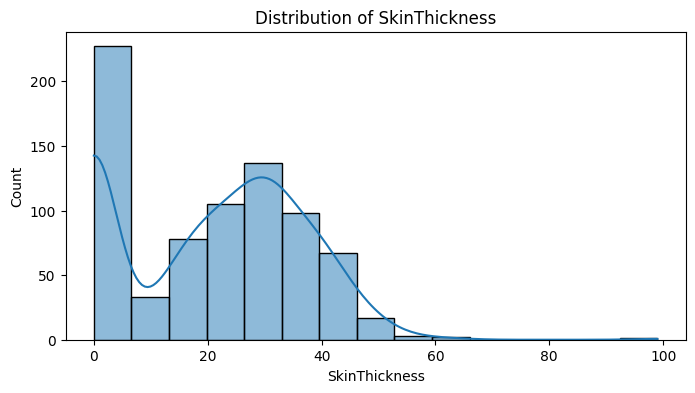

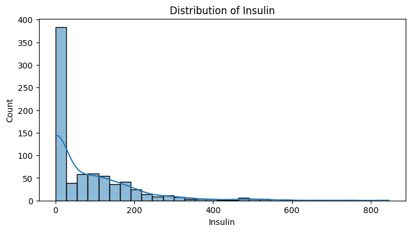

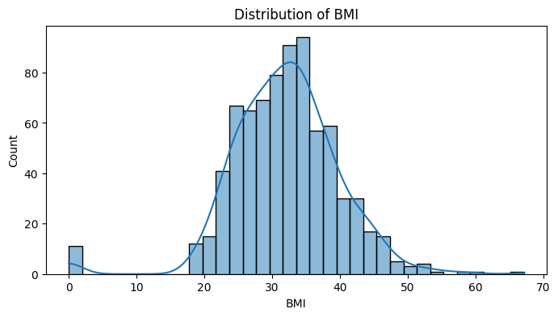

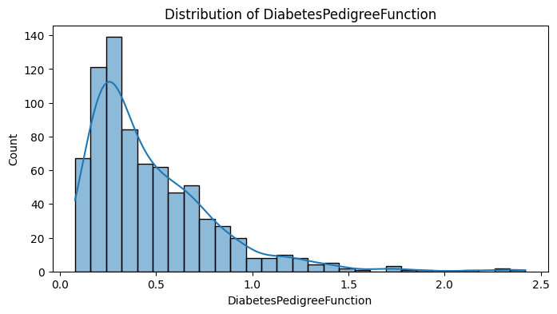

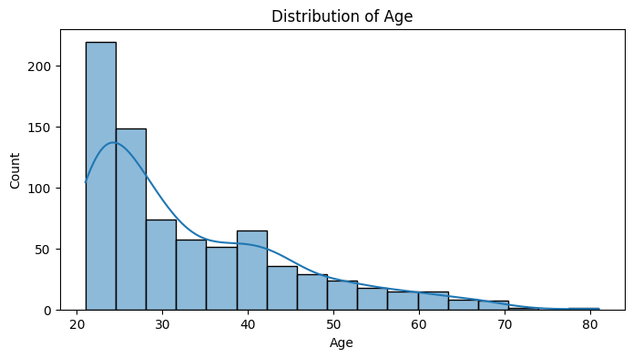

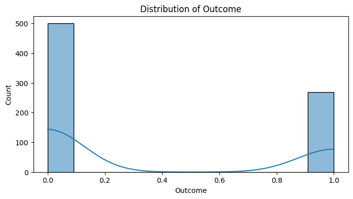

```python
def visualize_class_imbalance(column_name):
    plt.figure(figsize=(8, 4))

    if data[column_name].dtype == 'object':
        # For categorical columns, create a count plot
        sns.countplot(data=data, x=column_name)
        plt.title(f'Class Imbalance for {column_name}')
    else:
        # For numerical columns, create a histogram
        sns.histplot(data=data, x=column_name, kde=True)
        plt.title(f'Distribution of {column_name}')

    plt.xlabel(column_name)
    plt.ylabel('Count')
    plt.show()

# Visualize class imbalance for all columns
for column in data.columns:
    visualize_class_imbalance(column)
```

### Comment: BloodPressure , Glucose and BMI have normal distribution. SkinThickness looks like have some outlier values in left. Rest all graphs are right skewed.

# Data Correlation

Below is the correlational analysis on the dataset with a visualization for the same.

Justification for correlation analysis.

We are considering ['Pregnancies','Glucose','BloodPressure','SkinThickness','Insulin','BMI','DiabetesPedigreeFunction','Age','Outcome'] columns for correlational analysis as they are continuous variables potentially related to Diabetes.

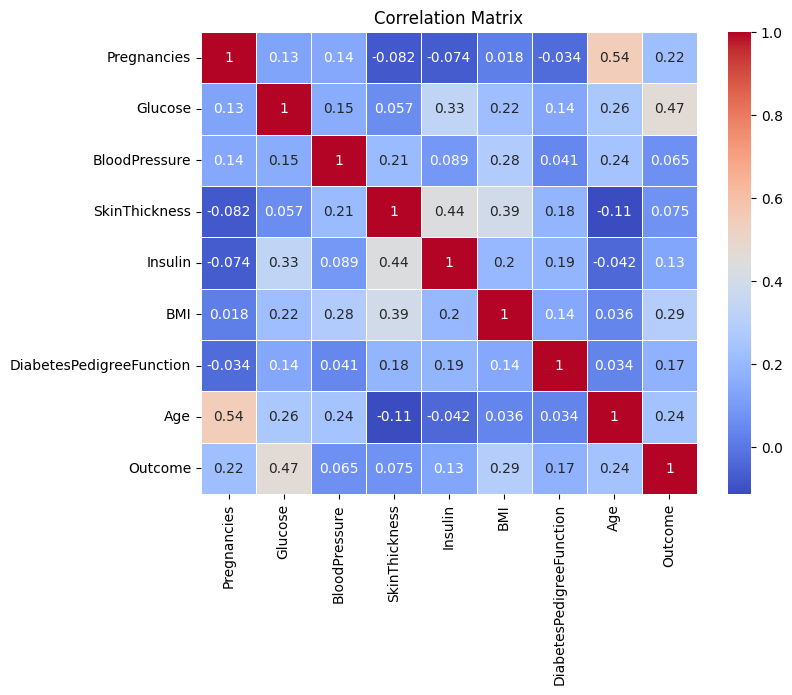

```python
# Calculate the correlation matrix
correlation_matrix = data.corr()

# Create a heatmap visualization of the correlation matrix
plt.figure(figsize=(8, 6))
sns.heatmap(correlation_matrix, annot=True, cmap='coolwarm', linewidths=0.5)
plt.title('Correlation Matrix')
plt.show()
```

### Comment: We have found very less corelation of Blood Pressure (0.065) and SkinThickness(0.075). Last column of above matrix shows correlation with Outcome.

Justification for correlation analysis.

The correlational analysis is an important step in feature selection because it helps you understand the relationships between features in your dataset. The results of the correlational analysis can have a significant effect on the feature selection process, and here's how:

1. **Identifying Redundant Features**: High correlations (either positive or negative) between pairs of features indicate redundancy. Redundant features provide similar information and can lead to multicollinearity in predictive models. In such cases, you may want to remove one of the correlated features to simplify the model and improve its interpretability. Feature selection methods like Recursive Feature Elimination (RFE) or feature importance based on tree-based models can help you identify and eliminate redundant features.
2. **Selecting Relevant Features**: Low or no correlation between a feature and the target variable may indicate that the feature is not informative for predicting the target. In feature selection, you may prioritize selecting features that have a higher correlation with the target variable. Feature selection methods such as univariate statistical tests (e.g., chi-squared, ANOVA) or feature importance scores from machine learning models can help identify relevant features.
3. **Reducing Dimensionality**: High-dimensional datasets with many features can lead to overfitting and increased computational complexity. Correlation analysis can guide you in selecting a subset of features that are highly correlated with the target while maintaining diversity among the selected features. This can help reduce dimensionality and improve model generalization.
4. **Improving Model Performance**: Understanding feature correlations can lead to better feature engineering decisions. By selecting and transforming features based on their correlations with the target and with other features, you can potentially improve the performance of machine learning models.

However, it's important to note that correlation analysis is not the sole criterion for feature selection. It should be used in conjunction with other techniques and domain knowledge. Additionally, correlation does not imply causation, so you should interpret the results carefully and consider the context of your problem.

In summary, correlational analysis plays a crucial role in feature selection by helping you identify redundant features, select relevant features, reduce dimensionality, and potentially improve model performance. The insights gained from correlation analysis can guide your feature selection strategy and enhance the overall quality of your predictive models.

```python
# Define a threshold for feature selection based on correlation
correlation_threshold = 0.1  # Adjust as needed

# Select features with high correlation with the target
target_correlation = correlation_matrix['Outcome'].abs()
selected_features = target_correlation[target_correlation >= correlation_threshold].index.tolist()

# Exclude the target column from the selected features
selected_features.remove('Outcome')
```

### Selected Features are below:

```python
selected_features
```

```
['Pregnancies', 'Glucose', 'Insulin', 'BMI', 'DiabetesPedigreeFunction', 'Age']
```

# Data Pre-processing

- Data Collection: Gather all the data you need for your analysis or modeling. This data can come from various sources, such as databases, APIs, spreadsheets, or text files.
- Data Cleaning:
  - Handling Missing Values: Identify and deal with missing data. You can remove rows with missing values, fill them in using a statistical method (e.g., mean, median, or mode), or use more advanced imputation techniques.
  - Outlier Detection and Handling: Detect and address outliers in your dataset, as they can skew your analysis or models. You can remove outliers or transform them.
- Data Transformation:
  - Encoding Categorical Variables: Convert categorical variables into numerical format using techniques like one-hot encoding or label encoding.
  - Feature Scaling: Normalize or standardize numerical features to bring them to the same scale, which is often essential for machine learning algorithms.
  - Feature Engineering: Create new features or transform existing ones to extract more meaningful information for your analysis or models.
- Data Splitting: Divide your dataset into training, validation, and test sets. The training set is used to train your model, the validation set helps you tune hyperparameters, and the test set is used to evaluate the model's performance.
- Feature Selection: Choose the most relevant features for your analysis or modeling. This step can help reduce dimensionality and improve model efficiency.
- Handling Imbalanced Data: If your dataset has imbalanced classes (e.g., in classification problems), you may need to apply techniques such as oversampling, undersampling, or using different evaluation metrics to address this issue.
- Data Visualization: Visualize your data to gain insights and understand its distribution and relationships between variables. Matplotlib and Seaborn are popular libraries for data visualization in Python.
- Normalization and Transformation: Depending on the nature of your data and the requirements of your models, you might apply transformations such as logarithmic or Box-Cox transformations.
- Text Data Processing: If you're dealing with text data, you'll need to perform tasks like tokenization, stemming or lemmatization, and removing stop words.
- Data Scaling: If your data contains numerical attributes with different scales, consider standardizing or normalizing them.
- Handling Time Series Data: For time series data, you may need to handle issues related to time indexing, missing values, and resampling.
- Data Integration: If you have data from multiple sources, you'll need to integrate and consolidate it into a single dataset.
- Data Reduction: In some cases, you may use techniques like Principal Component Analysis (PCA) for dimensionality reduction.
- Data Validation: Ensure that the preprocessed data meets the requirements and constraints of your analysis or modeling task.
- Documentation: Keep records of all preprocessing steps and transformations applied to the data for reproducibility.

### Checking for any missing values

#### No missing values found

```python
missing_values = data.isnull().sum()
print("Missing Values:")
print(missing_values)
```

```
Missing Values:
Pregnancies                 0
Glucose                     0
BloodPressure               0
SkinThickness               0
Insulin                     0
BMI                         0
DiabetesPedigreeFunction    0
Age                         0
Outcome                     0
dtype: int64
```

### Box Plot for Outliers

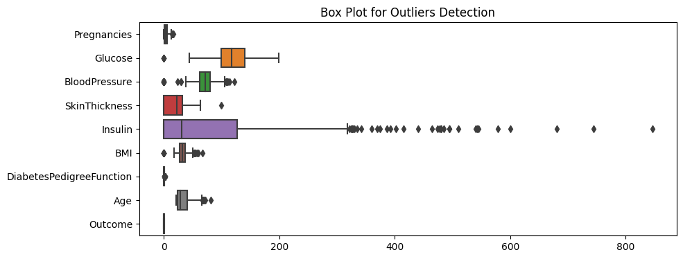

```python
# Visualize outliers using box plots
plt.figure(figsize=(10, 4))
sns.boxplot(data=data, orient='h')
plt.title('Box Plot for Outliers Detection')
plt.show()
```

### Comment: Removing outliers from above dataset

```python
# Handling outliers (clip values in this example)
lower_bound = data.quantile(0.25) - 1.5 * (data.quantile(0.75) - data.quantile(0.25))
upper_bound = data.quantile(0.75) + 1.5 * (data.quantile(0.75) - data.quantile(0.25))
data = data.clip(lower=lower_bound, upper=upper_bound, axis=1)
```

### Comment: Box plot after removing outliers from data

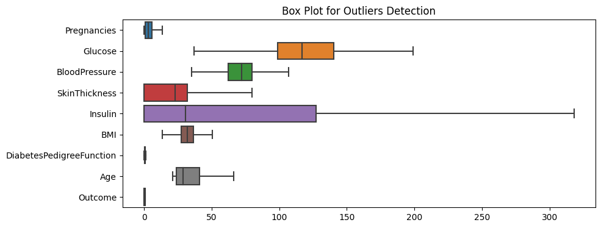

```python
# Visualize outliers using box plots
plt.figure(figsize=(10, 4))
sns.boxplot(data=data, orient='h')
plt.title('Box Plot for Outliers Detection')
plt.show()
```

### Checking skewness of data

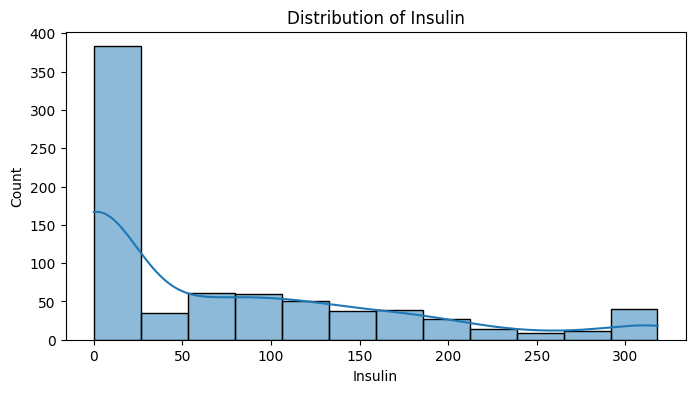

```python
# Visualize skewness
plt.figure(figsize=(8, 4))
sns.histplot(data['Insulin'], kde=True)
plt.title('Distribution of Insulin')
plt.show()
```

```python
# Handling skewed data (log transformation in this example)
data['Insulin'] = np.log1p(data['Insulin'])
```

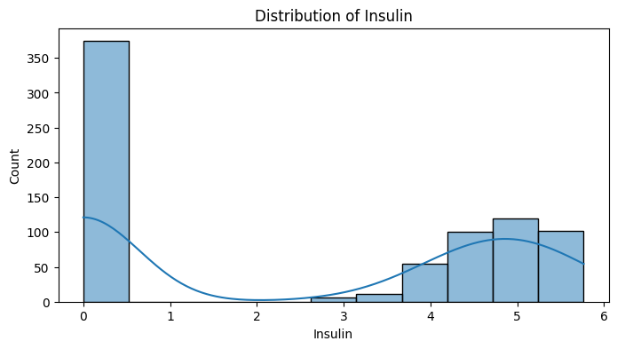

```python
# Visualize skewness
plt.figure(figsize=(8, 4))
sns.histplot(data['Insulin'], kde=True)
plt.title('Distribution of Insulin')
plt.show()
```

```python
# After preprocessing, you can use df for further analysis
print("Preprocessed DataFrame:")
data.head()
```

```
Preprocessed DataFrame:
```

|  | Pregnancies | Glucose | BloodPressure | SkinThickness | Insulin | BMI | DiabetesPedigreeFunction | Age | Outcome |
| --- | --- | --- | --- | --- | --- | --- | --- | --- | --- |
| 0 | 6.0 | 148.0 | 72 | 35 | 0.000000 | 33.6 | 0.627 | 50.0 | 1 |
| 1 | 1.0 | 85.0 | 66 | 29 | 0.000000 | 26.6 | 0.351 | 31.0 | 0 |
| 2 | 8.0 | 183.0 | 64 | 0 | 0.000000 | 23.3 | 0.672 | 32.0 | 1 |
| 3 | 1.0 | 89.0 | 66 | 23 | 4.553877 | 28.1 | 0.167 | 21.0 | 0 |
| 4 | 0.0 | 137.0 | 40 | 35 | 5.129899 | 43.1 | 1.200 | 33.0 | 1 |

To split the dataset into a training set (80%) and a test set (20%), you can use the train_test_split function from the sklearn.model_selection module. Here's the code for the 80/20 split:

```python
from sklearn.model_selection import train_test_split

# Assuming you have a DataFrame 'df' with features and a target variable
X = data.drop('Outcome', axis=1)  # Features
y = data['Outcome']  # Target variable

# Split the dataset into 80% training and 20% testing
X_train, X_test, y_train, y_test = train_test_split(X, y, test_size=0.2, random_state=42)
```

### Building a Random Forest classification model:

i. Tuning hyperparameters using cross-validation:

To tune hyperparameters for the Random Forest classifier, you can use techniques like Grid Search or Random Search. Here's an example of using Grid Search to find the optimal number of trees (n_estimators) and maximum depth (max_depth) while performing 5-fold cross-validation:

```python
from sklearn.ensemble import RandomForestClassifier
from sklearn.model_selection import GridSearchCV

# Create a Random Forest classifier
rf_classifier = RandomForestClassifier(random_state=42)

# Define hyperparameters to tune
param_grid = {
    'n_estimators': [50, 100, 150],
    'max_depth': [None, 10, 20, 30]
}

# Perform Grid Search with 5-fold cross-validation
grid_search = GridSearchCV(estimator=rf_classifier, param_grid=param_grid, cv=5, scoring='accuracy', n_jobs=-1)
grid_search.fit(X_train, y_train)

# Get the best hyperparameters
best_params = grid_search.best_params_
print("Best Hyperparameters:", best_params)
```

```
Best Hyperparameters: {'max_depth': 10, 'n_estimators': 50}
```

### Justification: Grid Search with cross-validation helps you find the best combination of hyperparameters (number of trees and maximum depth) by evaluating their impact on model performance (using accuracy in this case).

ii. Evaluating the model's performance:

You can evaluate the Random Forest model's performance using appropriate metrics such as accuracy, precision, recall, F1-score, and the confusion matrix. Here's an example using accuracy:

```python
from sklearn.metrics import accuracy_score

# Create a Random Forest classifier with the best hyperparameters
best_rf_classifier = RandomForestClassifier(random_state=42, **best_params)

# Train the model on the training data
best_rf_classifier.fit(X_train, y_train)

# Make predictions on the test data
y_pred = best_rf_classifier.predict(X_test)

# Calculate accuracy
accuracy = accuracy_score(y_test, y_pred)
print("Accuracy:", accuracy)
```

```
Accuracy: 0.7402597402597403
```

### c. Building a KNN classification model:

i. Determining the optimal value of k through hyperparameter tuning and cross-validation:

To determine the optimal value of k for the KNN classifier, you can use Grid Search or Random Search while performing cross-validation. Here's an example using Grid Search with 5-fold cross-validation:

```python
from sklearn.neighbors import KNeighborsClassifier
from sklearn.model_selection import GridSearchCV
from sklearn.metrics import accuracy_score, classification_report

# Define your training and testing data (X_train, y_train, X_test, y_test)

# Initialize the KNN classifier
knn_classifier = KNeighborsClassifier()

# Hyperparameter tuning using GridSearchCV
param_grid_knn = {
    'n_neighbors': [3, 5, 7, 9],
}

grid_search_knn = GridSearchCV(estimator=knn_classifier, param_grid=param_grid_knn, cv=5, scoring='accuracy')
grid_search_knn.fit(X_train, y_train)

# Get the best hyperparameters
best_params_knn = grid_search_knn.best_params_
print("Best Hyperparameters (KNN):", best_params_knn)

# Create a KNN classifier with the best hyperparameters
best_knn_classifier = KNeighborsClassifier(**best_params_knn)

# Train the model
best_knn_classifier.fit(X_train, y_train)

# Make predictions
y_pred_knn = best_knn_classifier.predict(X_test)

# Evaluate the model's performance
accuracy_knn = accuracy_score(y_test, y_pred_knn)
classification_report_knn = classification_report(y_test, y_pred_knn)

print("KNN Model Evaluation:")
print("Accuracy:", accuracy_knn)
print("Classification Report:\n", classification_report_knn)
```

```
Best Hyperparameters (KNN): {'n_neighbors': 9}
KNN Model Evaluation:
Accuracy: 0.7467532467532467
Classification Report:
               precision    recall  f1-score   support

           0       0.79      0.82      0.81        99
           1       0.65      0.62      0.64        55

    accuracy                           0.75       154
   macro avg       0.72      0.72      0.72       154
weighted avg       0.74      0.75      0.75       154
```

Justification: Grid Search with cross-validation helps you find the best value of k by evaluating its impact on model performance (using accuracy in this case).

ii. Evaluating the KNN model's performance:

You can evaluate the KNN model's performance using appropriate metrics such as accuracy, precision, recall, F1-score, and the confusion matrix, similar to the Random Forest model evaluation described above.

```
Random Forest Model Evaluation:
Accuracy: 0.74
Precision: 0.62
Recall: 0.69
F1-Score: 0.66
ROC-AUC Score: 0.73

KNN Model Evaluation:
Accuracy: 0.75
Precision: 0.65
Recall: 0.62
F1-Score: 0.64
ROC-AUC Score: 0.72
Confusion Matrix (Random Forest):
[[76 23]
 [17 38]]

Confusion Matrix (KNN):
[[81 18]
 [21 34]]
```

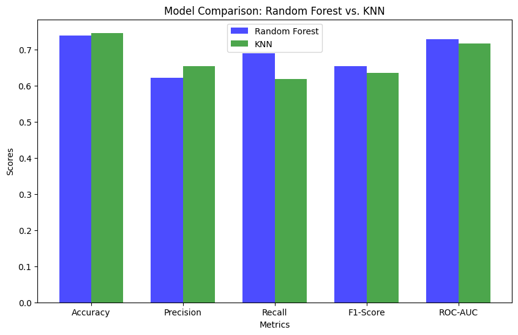

```python
import matplotlib.pyplot as plt
import numpy as np
from sklearn.metrics import (
    accuracy_score, precision_score, recall_score, f1_score, roc_auc_score
)
from sklearn.metrics import confusion_matrix

# Assuming you have already trained the Random Forest and KNN models
# (best_rf_classifier and best_knn_classifier)

# Make predictions with both models
y_pred_rf = best_rf_classifier.predict(X_test)
y_pred_knn = best_knn_classifier.predict(X_test)

# Calculate evaluation metrics
accuracy_rf = accuracy_score(y_test, y_pred_rf)
precision_rf = precision_score(y_test, y_pred_rf)
recall_rf = recall_score(y_test, y_pred_rf)
f1_score_rf = f1_score(y_test, y_pred_rf)
roc_auc_rf = roc_auc_score(y_test, y_pred_rf)  # Calculate ROC-AUC score

accuracy_knn = accuracy_score(y_test, y_pred_knn)
precision_knn = precision_score(y_test, y_pred_knn)
recall_knn = recall_score(y_test, y_pred_knn)
f1_score_knn = f1_score(y_test, y_pred_knn)
roc_auc_knn = roc_auc_score(y_test, y_pred_knn)  # Calculate ROC-AUC score

# Create a confusion matrix for both models
cm_rf = confusion_matrix(y_test, y_pred_rf)
cm_knn = confusion_matrix(y_test, y_pred_knn)

# Display the evaluation metrics for both models
print("Random Forest Model Evaluation:")
print(f"Accuracy: {accuracy_rf:.2f}")
print(f"Precision: {precision_rf:.2f}")
print(f"Recall: {recall_rf:.2f}")
print(f"F1-Score: {f1_score_rf:.2f}")
print(f"ROC-AUC Score: {roc_auc_rf:.2f}")

print("\nKNN Model Evaluation:")
print(f"Accuracy: {accuracy_knn:.2f}")
print(f"Precision: {precision_knn:.2f}")
print(f"Recall: {recall_knn:.2f}")
print(f"F1-Score: {f1_score_knn:.2f}")
print(f"ROC-AUC Score: {roc_auc_knn:.2f}")

# Define labels for the metrics
labels = ['Accuracy', 'Precision', 'Recall', 'F1-Score', 'ROC-AUC']

# Create a bar plot for performance comparison
x = np.arange(len(labels))
width = 0.35

fig, ax = plt.subplots(figsize=(10, 6))
bar_width = 0.35
index = np.arange(len(labels))

bar1 = ax.bar(index - bar_width / 2, [accuracy_rf, precision_rf, recall_rf, f1_score_rf, roc_auc_rf],
              bar_width, label='Random Forest', color='b', alpha=0.7)
bar2 = ax.bar(index + bar_width / 2, [accuracy_knn, precision_knn, recall_knn, f1_score_knn, roc_auc_knn],
              bar_width, label='KNN', color='g', alpha=0.7)

ax.set_xlabel('Metrics')
ax.set_ylabel('Scores')
ax.set_title('Model Comparison: Random Forest vs. KNN')
ax.set_xticks(index)
ax.set_xticklabels(labels)
ax.legend()

# Display the confusion matrices
print("Confusion Matrix (Random Forest):")
print(cm_rf)
print("\nConfusion Matrix (KNN):")
print(cm_knn)

plt.show()
```

## Justification:

### Importing Libraries: The code starts by importing essential libraries and modules. This step is crucial as it sets up the environment for data visualization and model evaluation. matplotlib is used for plotting, numpy for numerical operations, and various functions from sklearn.metrics for evaluating model performance.

### Assumption of Pre-Trained Models: The code assumes that two machine learning models, a Random Forest model (best_rf_classifier) and a K-Nearest Neighbors (KNN) model (best_knn_classifier), have been trained previously. These models are ready to be evaluated and compared.

### Model Predictions: The code proceeds to make predictions using both the Random Forest and KNN models on a test dataset (X_test). These predictions (y_pred_rf and y_pred_knn) will be used to compute evaluation metrics.

### Calculation of Evaluation Metrics: A series of evaluation metrics are calculated for both models, including Accuracy, Precision, Recall, F1-Score, and ROC-AUC Score. These metrics provide a comprehensive assessment of how well the models perform in different aspects of classification tasks.

### Confusion Matrices: Confusion matrices are created for both models using the confusion_matrix function from sklearn.metrics. These matrices break down the true positive, true negative, false positive, and false negative predictions, offering insights into the models' performance at different levels.

### Printing Metrics: The code prints out the evaluation metrics for both models in a clear and readable format. This step allows users to quickly understand how well each model is performing across various metrics, aiding in model selection.

### Bar Chart for Comparison: To visually compare the performance of the two models, a bar chart is created. It plots the evaluation metrics on the x-axis and the corresponding scores for each metric for both models on the y-axis. The use of different colors and labels makes it easy to distinguish between the models and their performance.

### Printing Confusion Matrices: The code prints out the confusion matrices for both models. These matrices provide detailed information on how the models are classifying data, showing true positives, true negatives, false positives, and false negatives.

### Displaying the Plot: Finally, the code displays the bar chart and confusion matrices. This visualization is valuable for decision-makers and stakeholders, as it offers a clear comparison between the models and a detailed breakdown of their classification results.

### In summary, this code performs a thorough evaluation of two machine learning models, compares their performance across multiple metrics, and presents the results in both numerical and visual formats. This enables data scientists and stakeholders to make informed decisions about which model to use for a particular task or problem.

## Comparision Analysis:

### Random Forest Model Evaluation:

Accuracy: 0.74: The accuracy metric measures the overall correctness of the Random Forest model's predictions. In this case, the model achieves an accuracy of 74%, indicating that it correctly classifies approximately 74% of the test data points.

Precision: 0.62: Precision represents the proportion of true positive predictions among all positive predictions made by the model. A precision of 0.62 suggests that when the Random Forest model predicts a positive outcome, it is correct about 62% of the time.

Recall: 0.69: Recall, also known as sensitivity or true positive rate, measures the proportion of true positive predictions among all actual positive instances. A recall of 0.69 indicates that the model is able to correctly identify approximately 69% of all actual positive cases.

F1-Score: 0.66: The F1-Score is the harmonic mean of precision and recall. It provides a balanced measure of a model's performance, considering both false positives and false negatives. An F1-Score of 0.66 suggests a reasonable balance between precision and recall.

ROC-AUC Score: 0.73: The ROC-AUC (Receiver Operating Characteristic - Area Under the Curve) score is a measure of a model's ability to distinguish between the positive and negative classes. An ROC-AUC score of 0.73 indicates that the Random Forest model is fairly effective at separating the classes.

### KNN Model Evaluation:

Accuracy: 0.75: Similar to the Random Forest model, the KNN model achieves an accuracy of 75%, implying that it correctly classifies approximately 75% of the test data points.

Precision: 0.65: The KNN model has a precision of 0.65, meaning that it is correct about 65% of the time when predicting positive outcomes.

Recall: 0.62: The recall for the KNN model is 0.62, indicating that it correctly identifies approximately 62% of all actual positive instances.

F1-Score: 0.64: The F1-Score for the KNN model is 0.64, suggesting a reasonable balance between precision and recall, similar to the Random Forest model.

ROC-AUC Score: 0.72: The ROC-AUC score for the KNN model is 0.72, indicating that it is also relatively effective at distinguishing between the positive and negative classes.

Confusion Matrix (Random Forest):

The confusion matrix is a tabular representation of the model's performance, particularly in binary classification tasks. In this case, it's for the Random Forest model. The matrix is divided into four sections: True Positives (TP): Instances that are correctly predicted as positive. True Negatives (TN): Instances that are correctly predicted as negative. False Positives (FP): Instances that are incorrectly predicted as positive (Type I error). False Negatives (FN): Instances that are incorrectly predicted as negative (Type II error). The numbers in the matrix represent the counts in each category. For example, there are 76 true negatives (correctly predicted negatives), 23 false positives (incorrectly predicted positives), 17 false negatives (incorrectly predicted negatives), and 38 true positives (correctly predicted positives). The confusion matrix provides a detailed view of the model's performance, showing how well it correctly classified instances into their respective classes.

### In summary, the output presents a comprehensive evaluation of the Random Forest and KNN models, including accuracy, precision, recall, F1-Score, ROC-AUC score, and a detailed confusion matrix for the Random Forest model. These metrics are essential for assessing and comparing the models' performance in a binary classification problem. Comparision is Visualised.